```r
here::i_am(
  "report.Rmd"
)
```

```
## here() starts at /Users/sunhuiqing/Desktop/Info 550/Info Final Project
```

# Data Intro

The data set I chose is from [Kaggle web, Breast Cancer Data Folder](https://www.kaggle.com/datasets/reihanenamdari/breast-cancer), which provides information on population-based cancer statistics.

This data set involves female breast cancer patients diagnosed with invasive ductal and lobular carcinoma from 2006-2010. 4024 patients were finally included, excluding patients with unknown tumor size, examined regional lymph nodes, positive regional lymphatic vessels, and survival months less than 1 month.

I want to create a R Markdown report mainly about exploring * which variables are related to breast cancer * how exactly they are related to

Some useful description about the variables:

Grade: A low grade number (grade 1) usually means the cancer is slower-growing and less likely to spread, while a higher grade number means a faster-growing cancer that’s more likely to spread.

Estrogen and Progesterone Status: If breast cancer cells have estrogen receptors, the cancer is called ER-positive breast cancer. If breast cancer cells have progesterone receptors, the cancer is called PR-positive breast cancer. If the cells do not have either of these 2 receptors, the cancer is called ER/PR-negative.

```r
data <- readRDS(
  file=here::here("data/data_clean.rds")
)
head(data)
```

```
##   Age  Race Marital.Status T.Stage N.Stage X6th.Stage             differentiate
## 1  68 White        Married      T1      N1        IIA     Poorly differentiated
## 2  50 White        Married      T2      N2       IIIA Moderately differentiated
## 3  58 White       Divorced      T3      N3       IIIC Moderately differentiated
## 4  58 White        Married      T1      N1        IIA     Poorly differentiated
## 5  47 White        Married      T2      N1        IIB     Poorly differentiated
## 6  51 White        Single       T1      N1        IIA Moderately differentiated
##   Grade  A.Stage Tumor.Size Estrogen.Status Progesterone.Status
## 1     3 Regional          4        Positive            Positive
## 2     2 Regional         35        Positive            Positive
## 3     2 Regional         63        Positive            Positive
## 4     3 Regional         18        Positive            Positive
## 5     3 Regional         41        Positive            Positive
## 6     2 Regional         20        Positive            Positive
##   Regional.Node.Examined Reginol.Node.Positive Survival.Months Status
## 1                     24                     1              60  Alive
## 2                     14                     5              62  Alive
## 3                     14                     7              75  Alive
## 4                      2                     1              84  Alive
## 5                      3                     1              50  Alive
## 6                     18                     2              89  Alive
```

The table blow shows alive status in terms of Grade, Race, Marital Status and Estrogen Status.

```r
readRDS(
  file = here::here("output/table_one.rds")
)
```

| **Characteristic** | **Overall**, N = 4,024<sup>1</sup> | **Summary** **Alive**, N = 3,408<sup>1</sup> | **Summary** **Dead**, N = 616<sup>1</sup> | **p-value**<sup>2</sup> |  |
| --- | --- | --- | --- | --- | --- |
| Grade |  |  |  |  | <0.001 |
| anaplastic; Grade IV | 19 (0.5%) | 10 (0.3%) | 9 (1.5%) |  |  |
| 1 | 543 (13%) | 504 (15%) | 39 (6.3%) |  |  |
| 2 | 2,351 (58%) | 2,046 (60%) | 305 (50%) |  |  |
| 3 | 1,111 (28%) | 848 (25%) | 263 (43%) |  |  |
| Race |  |  |  | <0.001 |  |
| Black | 291 (7.2%) | 218 (6.4%) | 73 (12%) |  |  |
| Other | 320 (8.0%) | 287 (8.4%) | 33 (5.4%) |  |  |
| White | 3,413 (85%) | 2,903 (85%) | 510 (83%) |  |  |
| Marital.Status |  |  |  | <0.001 |  |
| Divorced | 486 (12%) | 396 (12%) | 90 (15%) |  |  |
| Married | 2,643 (66%) | 2,285 (67%) | 358 (58%) |  |  |
| Separated | 45 (1.1%) | 30 (0.9%) | 15 (2.4%) |  |  |
| Single | 615 (15%) | 511 (15%) | 104 (17%) |  |  |
| Widowed | 235 (5.8%) | 186 (5.5%) | 49 (8.0%) |  |  |
| Estrogen.Status |  |  |  | <0.001 |  |
| Negative | 269 (6.7%) | 161 (4.7%) | 108 (18%) |  |  |
| Positive | 3,755 (93%) | 3,247 (95%) | 508 (82%) |  |  |

<sup>1</sup> n (%)  
<sup>2</sup> Fisher's exact test; Pearson's Chi-squared test

## Graphical analysis

For Figure5, It turns out that women ages between 45 to 65 are most suffer from Brest Cancer.

For Figure6, It shows that patients in Grade 4 stage of breast cancer has bigger sized tumour compair to Grade 1,2 and 3.

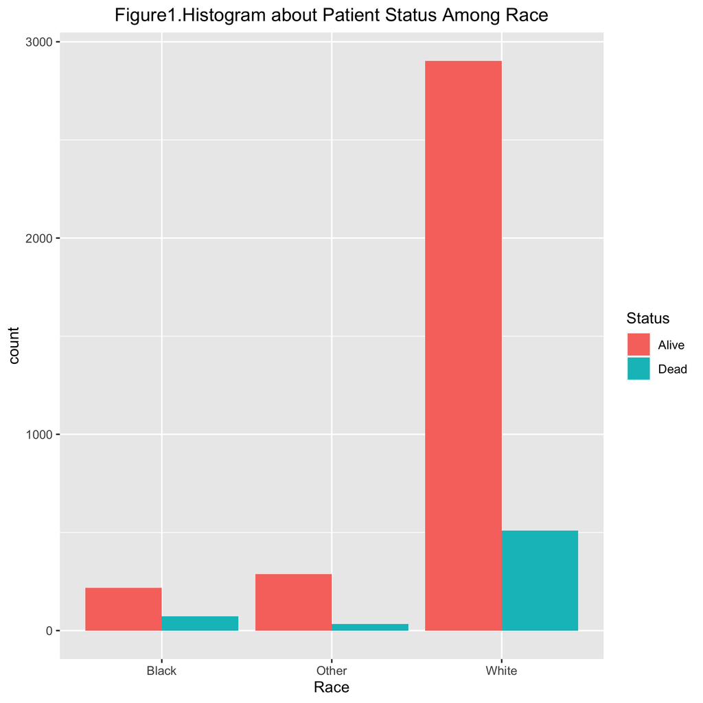

```r
knitr::include_graphics(
  here::here("output/fig1.png")
)
```

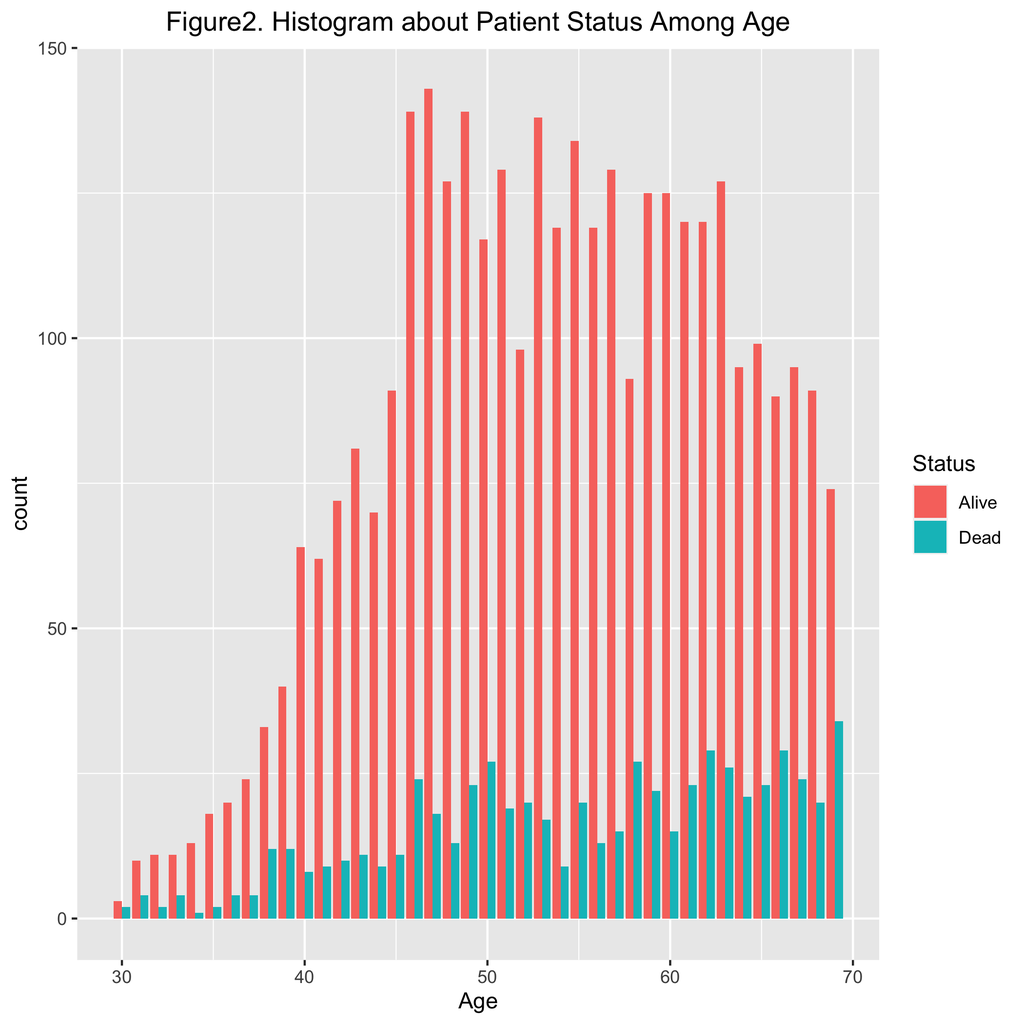

```r
knitr::include_graphics(
  here::here("output/fig2.png")
)
```

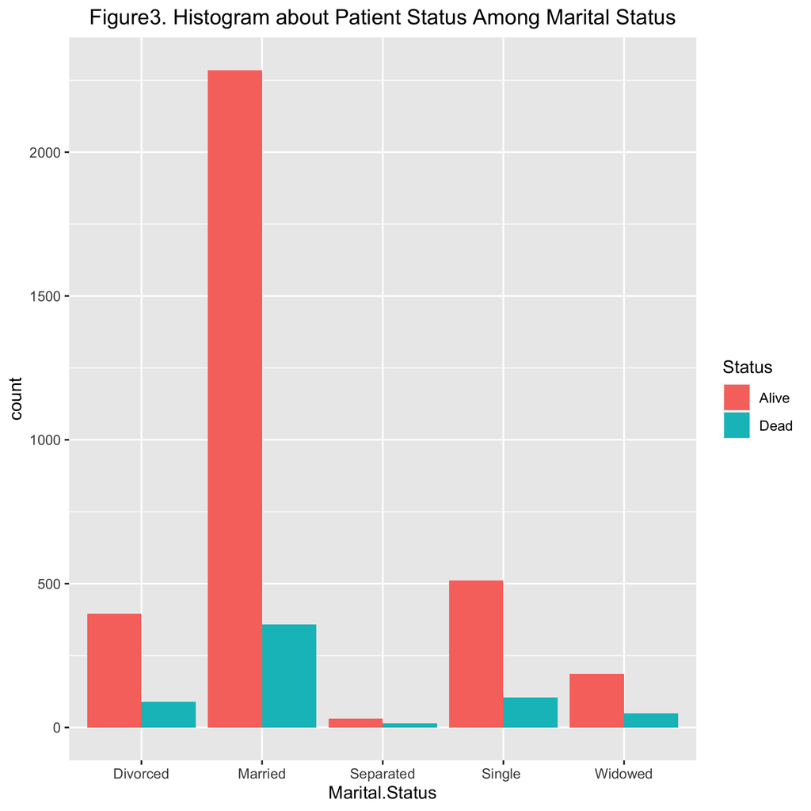

```r
knitr::include_graphics(
  here::here("output/fig3.png")
)
```

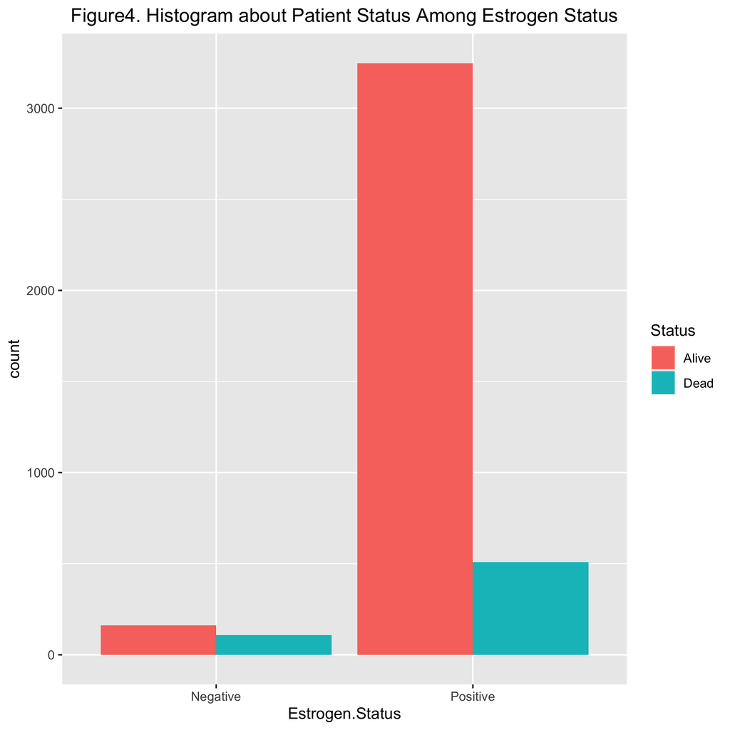

```r
knitr::include_graphics(
  here::here("output/fig4.png")
)
```

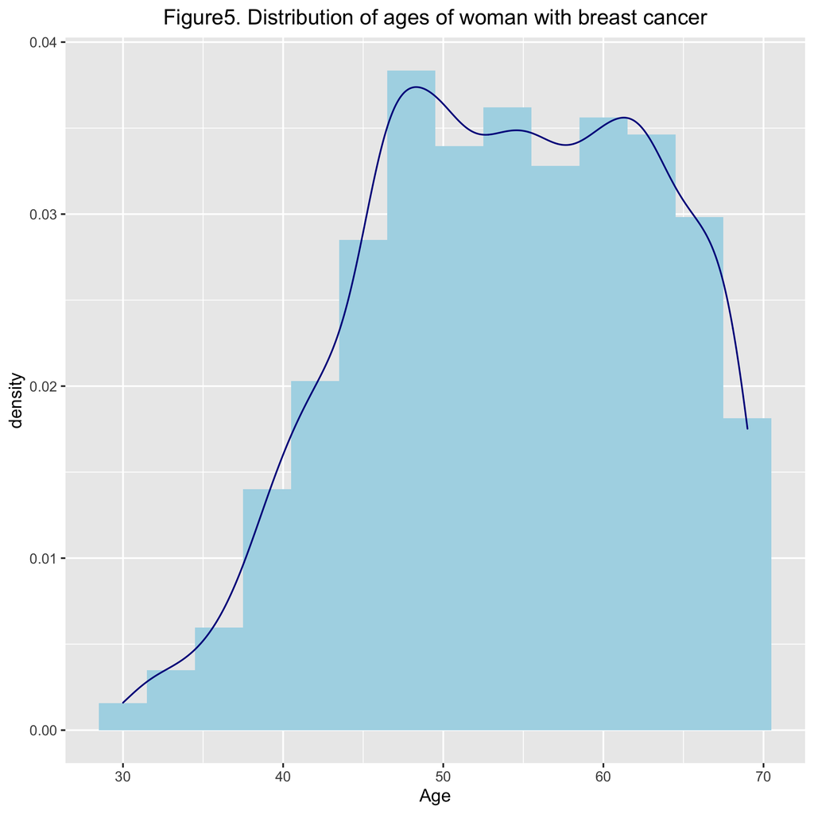

```r
knitr::include_graphics(
  here::here("output/fig5.png")
)
```

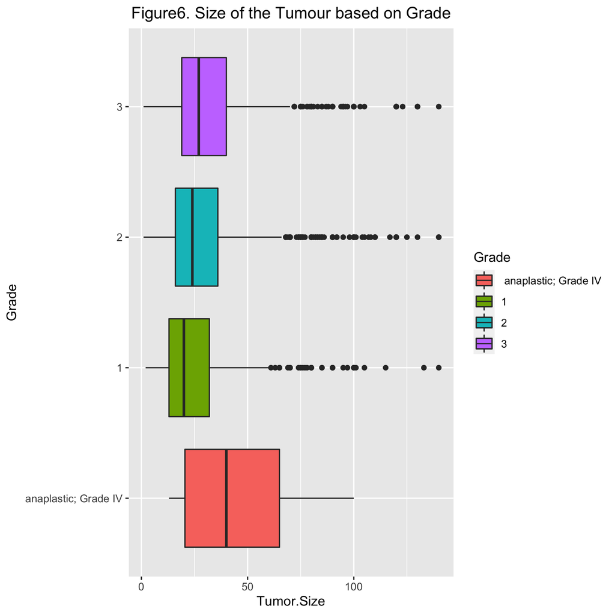

```r
knitr::include_graphics(
  here::here("output/fig6.png")
)
```